# Practical ML project

Amirsaman Hamzeh

## Data preprocessing

In this section, we read the data files, clean them by taking care of NAs and highly correlated variables.

```
## 'data.frame':    19622 obs. of  160 variables:
##  $ X                       : int  1 2 3 4 5 6 7 8 9 10 ...
##  $ user_name               : Factor w/ 6 levels "adelmo","carlitos",..: 2 2 2 2 2 2 2 2 2 2 ...
##  $ raw_timestamp_part_1    : int  1323084231 1323084231 1323084231 1323084232 1323084232 1323084232 1323084232 1323084232 1323084232 1323084232 ...
##  $ raw_timestamp_part_2    : int  788290 808298 820366 120339 196328 304277 368296 440390 484323 484434 ...
##  $ cvtd_timestamp          : Factor w/ 20 levels "02/12/2011 13:32",..: 9 9 9 9 9 9 9 9 9 9 ...
##  $ new_window              : Factor w/ 2 levels "no","yes": 1 1 1 1 1 1 1 1 1 1 ...
##  $ num_window              : int  11 11 11 12 12 12 12 12 12 12 ...
##  $ roll_belt               : num  1.41 1.41 1.42 1.48 1.48 1.45 1.42 1.42 1.43 1.45 ...
##  $ pitch_belt              : num  8.07 8.07 8.07 8.05 8.07 8.06 8.09 8.13 8.16 8.17 ...
##  $ yaw_belt                : num  -94.4 -94.4 -94.4 -94.4 -94.4 -94.4 -94.4 -94.4 -94.4 -94.4 ...
##  $ total_accel_belt        : int  3 3 3 3 3 3 3 3 3 3 ...
##  $ kurtosis_roll_belt      : Factor w/ 397 levels "","-0.016850",..: 1 1 1 1 1 1 1 1 1 1 ...
##  $ kurtosis_picth_belt     : Factor w/ 317 levels "","-0.021887",..: 1 1 1 1 1 1 1 1 1 1 ...
##  $ kurtosis_yaw_belt       : Factor w/ 2 levels "","#DIV/0!": 1 1 1 1 1 1 1 1 1 1 ...
```

[output cut: 86 more lines]

There are 160 variables in each dataset, most of which seem to have high percentage of NA values. Having found these variables, we can drop them from the both data sets. A number of factor variables have meaningless data and can be dropped from the dataset including “kurtosis_yaw_belt”, “skewness_yaw_belt”, “amplitude_yaw_belt”, “kurtosis_yaw_dumbbell”, “skewness_yaw_dumbbell”, “amplitude_yaw_dumbbell”, “kurtosis_yaw_forearm”, “skewness_yaw_forearm”, “amplitude_yaw_forearm”. Finally we do not need name and time related variables so we can drop them as well.

```r
for (i in names(nalist[nalist>0])){
    training[,eval(i)] <- NULL
    testing[,eval(i)] <- NULL
}

droppedfactorvars <- c("kurtosis_yaw_belt", "skewness_yaw_belt", "amplitude_yaw_belt", "kurtosis_yaw_dumbbell", "skewness_yaw_dumbbell", "amplitude_yaw_dumbbell", "kurtosis_yaw_forearm", "skewness_yaw_forearm", "amplitude_yaw_forearm")
for (i in droppedfactorvars){
    training[,eval(i)] <- NULL
    testing[,eval(i)] <- NULL
}

droppedtimevars <- c("user_name","raw_timestamp_part_1","raw_timestamp_part_2","cvtd_timestamp")
for (i in droppedtimevars){
    training[,eval(i)] <- NULL
    testing[,eval(i)] <- NULL
}

droppedemptyvars <- c("kurtosis_roll_belt","kurtosis_picth_belt","skewness_roll_belt","skewness_roll_belt.1","max_yaw_belt","min_yaw_belt","kurtosis_roll_arm","kurtosis_picth_arm","kurtosis_yaw_arm","skewness_roll_arm","skewness_pitch_arm","skewness_yaw_arm","kurtosis_roll_dumbbell","kurtosis_picth_dumbbell","skewness_roll_dumbbell","skewness_pitch_dumbbell","max_yaw_dumbbell","min_yaw_dumbbell","kurtosis_roll_forearm","kurtosis_picth_forearm","skewness_roll_forearm","skewness_pitch_forearm","max_yaw_forearm","min_yaw_forearm")
for (i in droppedemptyvars){
    training[,eval(i)] <- NULL
    testing[,eval(i)] <- NULL
}
```

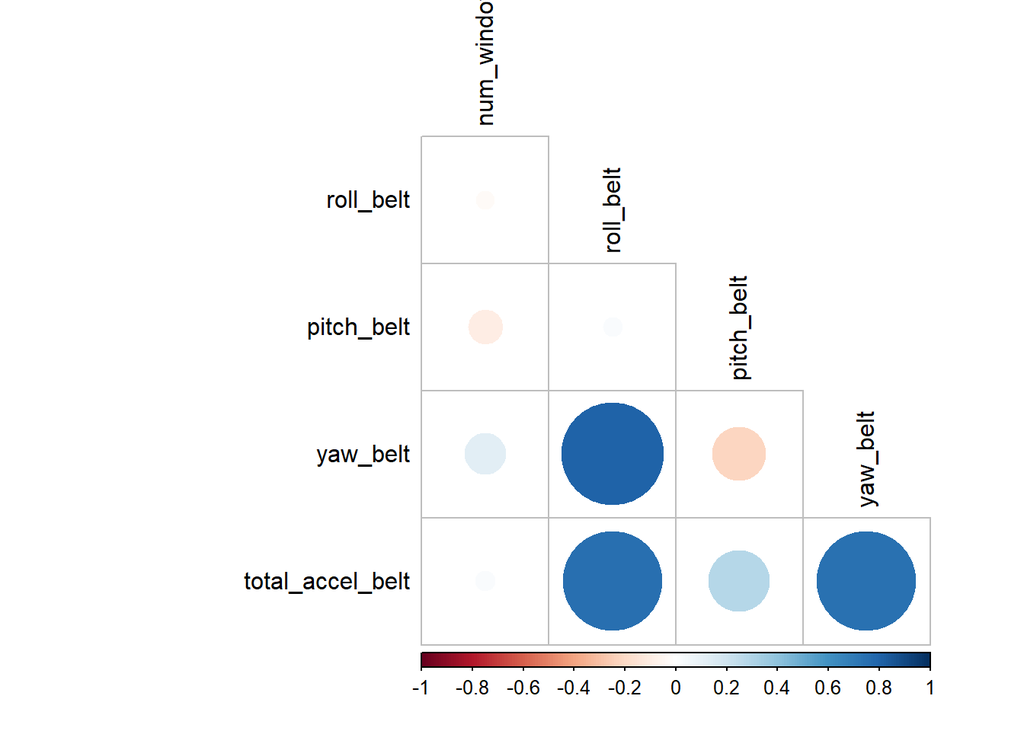

```r
training[,3:7] %>% cor(use="complete.obs",method="spearman") %>% corrplot(type="lower",tl.col="black",diag=FALSE)
```

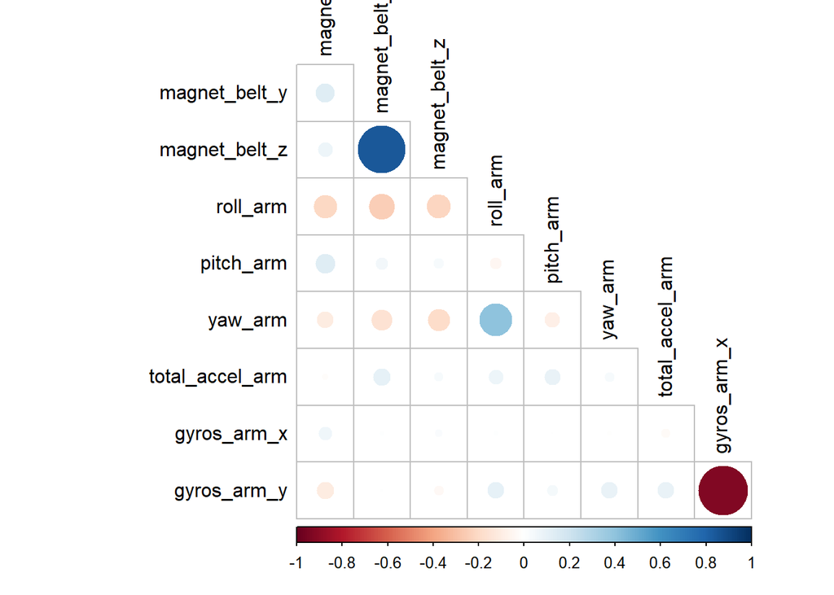

```r
training[,14:22] %>% cor(use="complete.obs",method="spearman") %>% corrplot(type="lower",tl.col="black",diag=FALSE)
```

## Cross Validation

We make a training and validating dataset from the main training data and fit a model using various methods.

```r
set.seed(12345)
inTrain <- createDataPartition(y=training$X,p=0.7,list=FALSE)
train <- training[inTrain,]
validation <- training[-inTrain,]
setting <- trainControl(method="cv", 10)
```

First we apply Decision Trees using rpart and caret packages. It turns out that rpart outperforms caret comparing their accuracies.

```r
modFitDT <- train(classe ~ ., data = subset(train,select = -X),method="rpart",trControl=setting)
DTpredicted <- predict(modFitDT,validation)
confusionMatrix(DTpredicted, validation$classe)
```

```
## Confusion Matrix and Statistics
##
##           Reference
## Prediction    A    B    C    D    E
##          A 1526  434  466  433  179
##          B   27  392   29  170  151
##          C  130  291  523  362  314
##          D    0    0    0    0    0
##          E    6    0    0    0  451
##
## Overall Statistics
##
##                Accuracy : 0.4915
##                  95% CI : (0.4787, 0.5044)
##     No Information Rate : 0.287
##     P-Value [Acc > NIR] : < 2.2e-16
##
##                   Kappa : 0.3352
##  Mcnemar's Test P-Value : NA
##
## Statistics by Class:
##
##                      Class: A Class: B Class: C Class: D Class: E
## Sensitivity            0.9035  0.35094  0.51375    0.000  0.41187
## Specificity            0.6396  0.92091  0.77456    1.000  0.99875
## Pos Pred Value         0.5023  0.50975  0.32284      NaN  0.98687
## Neg Pred Value         0.9427  0.85826  0.88391    0.836  0.88133
## Prevalence             0.2870  0.18984  0.17301    0.164  0.18610
## Detection Rate         0.2593  0.06662  0.08889    0.000  0.07665
## Detection Prevalence   0.5163  0.13069  0.27532    0.000  0.07767
## Balanced Accuracy      0.7715  0.63593  0.64416    0.500  0.70531
```

```r
modFitDT <- rpart(classe ~ ., data = subset(train,select = -X), method="class", control = rpart.control(method = "cv", number = 10))
DTpredicted <- predict(modFitDT,validation,type="class")
confusionMatrix(DTpredicted, validation$classe)
```

```
## Confusion Matrix and Statistics
##
##           Reference
## Prediction    A    B    C    D    E
##          A 1433  151   28   49   83
##          B  139  734   96  107  119
##          C    7   67  800  139   79
##          D   84  133   62  620  147
##          E   26   32   32   50  667
##
## Overall Statistics
##
##                Accuracy : 0.723
##                  95% CI : (0.7113, 0.7344)
##     No Information Rate : 0.287
##     P-Value [Acc > NIR] : < 2.2e-16
##
##                   Kappa : 0.6492
##  Mcnemar's Test P-Value : < 2.2e-16
##
## Statistics by Class:
##
##                      Class: A Class: B Class: C Class: D Class: E
## Sensitivity            0.8484   0.6571   0.7859   0.6425   0.6091
## Specificity            0.9259   0.9033   0.9400   0.9134   0.9708
## Pos Pred Value         0.8217   0.6142   0.7326   0.5927   0.8265
## Neg Pred Value         0.9382   0.9183   0.9545   0.9287   0.9157
## Prevalence             0.2870   0.1898   0.1730   0.1640   0.1861
## Detection Rate         0.2435   0.1247   0.1360   0.1054   0.1134
## Detection Prevalence   0.2964   0.2031   0.1856   0.1778   0.1372
## Balanced Accuracy      0.8871   0.7802   0.8629   0.7779   0.7899
```

```r
modFitDT <- rpart(classe ~ ., data = subset(train,select = -X), method="class")
DTpredicted <- predict(modFitDT,validation,type="class")
confusionMatrix(DTpredicted, validation$classe)
```

```
## Confusion Matrix and Statistics
##
##           Reference
## Prediction    A    B    C    D    E
##          A 1433  151   28   49   83
##          B  139  734   96  107  119
##          C    7   67  800  139   79
##          D   84  133   62  620  147
##          E   26   32   32   50  667
##
## Overall Statistics
##
##                Accuracy : 0.723
##                  95% CI : (0.7113, 0.7344)
##     No Information Rate : 0.287
##     P-Value [Acc > NIR] : < 2.2e-16
##
##                   Kappa : 0.6492
##  Mcnemar's Test P-Value : < 2.2e-16
##
## Statistics by Class:
##
##                      Class: A Class: B Class: C Class: D Class: E
## Sensitivity            0.8484   0.6571   0.7859   0.6425   0.6091
## Specificity            0.9259   0.9033   0.9400   0.9134   0.9708
## Pos Pred Value         0.8217   0.6142   0.7326   0.5927   0.8265
## Neg Pred Value         0.9382   0.9183   0.9545   0.9287   0.9157
## Prevalence             0.2870   0.1898   0.1730   0.1640   0.1861
## Detection Rate         0.2435   0.1247   0.1360   0.1054   0.1134
## Detection Prevalence   0.2964   0.2031   0.1856   0.1778   0.1372
## Balanced Accuracy      0.8871   0.7802   0.8629   0.7779   0.7899
```

```r
modFitRF <- train(classe ~ ., data = subset(train,select = -X),method="rf",trControl=trainControl(method="cv", 10))
RFpredicted <- predict(modFitRF,validation)
confusionMatrix(RFpredicted, validation$classe)
```

```
## Confusion Matrix and Statistics
##
##           Reference
## Prediction    A    B    C    D    E
##          A 1688    7    0    0    0
##          B    0 1107    0    0    0
##          C    0    2 1018    5    0
##          D    0    1    0  960    0
##          E    1    0    0    0 1095
##
## Overall Statistics
##
##                Accuracy : 0.9973
##                  95% CI : (0.9956, 0.9984)
##     No Information Rate : 0.287
##     P-Value [Acc > NIR] : < 2.2e-16
##
##                   Kappa : 0.9966
##  Mcnemar's Test P-Value : NA
##
## Statistics by Class:
##
##                      Class: A Class: B Class: C Class: D Class: E
## Sensitivity            0.9994   0.9910   1.0000   0.9948   1.0000
## Specificity            0.9983   1.0000   0.9986   0.9998   0.9998
## Pos Pred Value         0.9959   1.0000   0.9932   0.9990   0.9991
## Neg Pred Value         0.9998   0.9979   1.0000   0.9990   1.0000
## Prevalence             0.2870   0.1898   0.1730   0.1640   0.1861
## Detection Rate         0.2869   0.1881   0.1730   0.1632   0.1861
## Detection Prevalence   0.2881   0.1881   0.1742   0.1633   0.1863
## Balanced Accuracy      0.9989   0.9955   0.9993   0.9973   0.9999
```

```r
modFitBt <- train(classe ~ ., method = "gbm", data = subset(train,select = -X),verbose = F,trControl = setting)
BTpredicted <- predict(modFitBt,validation)
confusionMatrix(BTpredicted, validation$classe)
```

```
## Confusion Matrix and Statistics
##
##           Reference
## Prediction    A    B    C    D    E
##          A 1681   16    0    0    0
##          B    8 1083    7    8    4
##          C    0   16 1006   18    0
##          D    0    2    5  938    9
##          E    0    0    0    1 1082
##
## Overall Statistics
##
##                Accuracy : 0.984
##                  95% CI : (0.9805, 0.9871)
##     No Information Rate : 0.287
##     P-Value [Acc > NIR] : < 2.2e-16
##
##                   Kappa : 0.9798
##  Mcnemar's Test P-Value : NA
##
## Statistics by Class:
##
##                      Class: A Class: B Class: C Class: D Class: E
## Sensitivity            0.9953   0.9696   0.9882   0.9720   0.9881
## Specificity            0.9962   0.9943   0.9930   0.9967   0.9998
## Pos Pred Value         0.9906   0.9757   0.9673   0.9832   0.9991
## Neg Pred Value         0.9981   0.9929   0.9975   0.9945   0.9973
## Prevalence             0.2870   0.1898   0.1730   0.1640   0.1861
## Detection Rate         0.2857   0.1841   0.1710   0.1594   0.1839
## Detection Prevalence   0.2884   0.1886   0.1768   0.1621   0.1841
## Balanced Accuracy      0.9957   0.9819   0.9906   0.9844   0.9940
```

## Prediction

The Random Forest algorithm shows a good performance and is applied on the testing data to find predicted values.

```r
test_pred <- predict(modFitRF,testing)
```

## Submission on file

```r
write.csv(test_pred,"output.csv")
print(test_pred)
```

```
##  [1] B A B A A E D B A A B C B A E E A B B B
## Levels: A B C D E
```